# “Cell type annotation”

Cankun Wang

11/30/2022

# 1 Set working dir

```
## [1] "Current working directory: C:/Users/flyku/Documents/GitHub/BMBL-analysis-notebooks/scRNAseq_multi_sample_analysis"
```

# 2 Exploring known cell type markers

With the cells clustered, we can explore the cell type identities by looking for known markers. The UMAP plot with clusters marked is shown, followed by the different cell types expected.

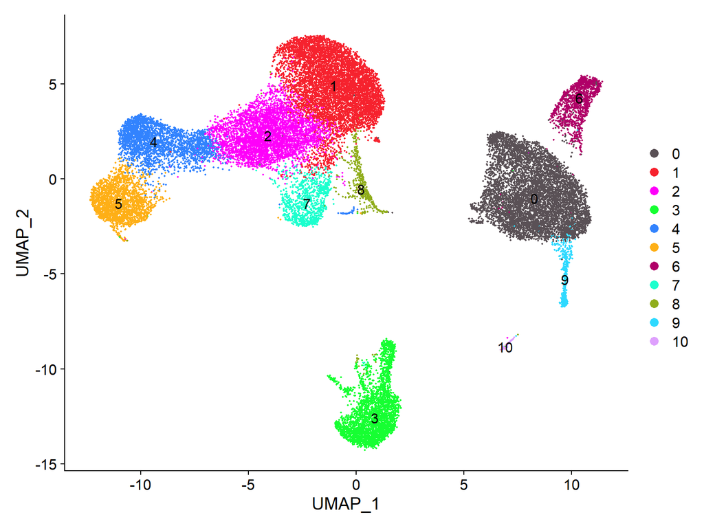

| Cell Type | Marker |
| --- | --- |
| CD14+ monocytes | CD14, LYZ |
| FCGR3A+ monocytes | FCGR3A, MS4A7 |
| Conventional dendritic cells | FCER1A, CST3 |
| Plasmacytoid dendritic cells | IL3RA, GZMB, SERPINF1, ITM2C |
| B cells | CD79A, MS4A1 |
| T cells | CD3D |
| CD4+ T cells | CD3D, IL7R, CCR7 |
| CD8+ T cells | CD3D, CD8A |
| NK cells | GNLY, NKG7 |
| Megakaryocytes | PPBP |
| Erythrocytes | HBB, HBA2 |

```r
# Select the RNA counts slot to be the default assay
DefaultAssay(combined) <- "RNA"

# Normalize RNA data for visualization purposes
combined <- NormalizeData(combined, verbose = FALSE)
```

Depending on our markers of interest, they could be positive or negative markers for a particular cell type. The combined expression of our chosen handful of markers should give us an idea on whether a cluster corresponds to that particular cell type.

For the markers used here, we are looking for positive markers and consistency of expression of the markers across the clusters. For example, if there are two markers for a cell type and only one of them is expressed in a cluster - then we cannot reliably assign that cluster to the cell type.

**CD14+ monocyte markers**

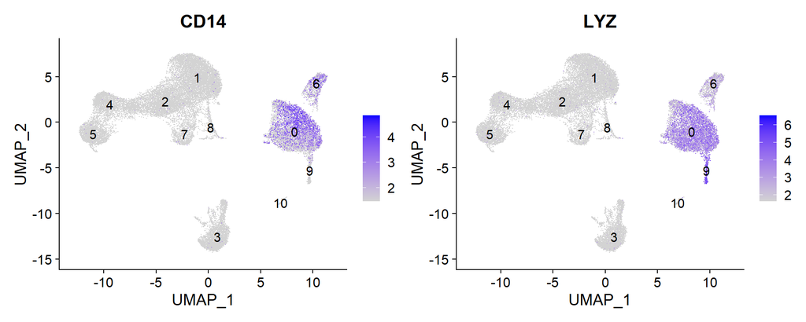

```r
FeaturePlot(combined,
            reduction = "umap",
            features = c("CD14", "LYZ"),
            order = TRUE,
            min.cutoff = 'q10',
            label = TRUE)
```

**FCGR3A+ monocyte markers**

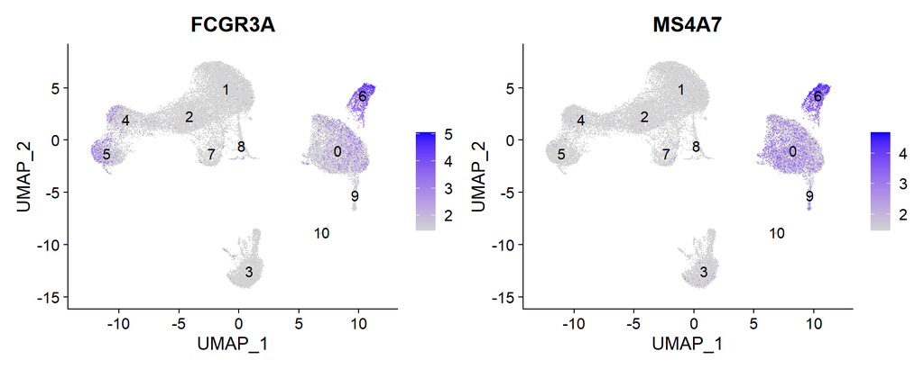

```r
FeaturePlot(combined,
            reduction = "umap",
            features = c("FCGR3A", "MS4A7"),
            order = TRUE,
            min.cutoff = 'q10',
            label = TRUE)
```

**Macrophages**

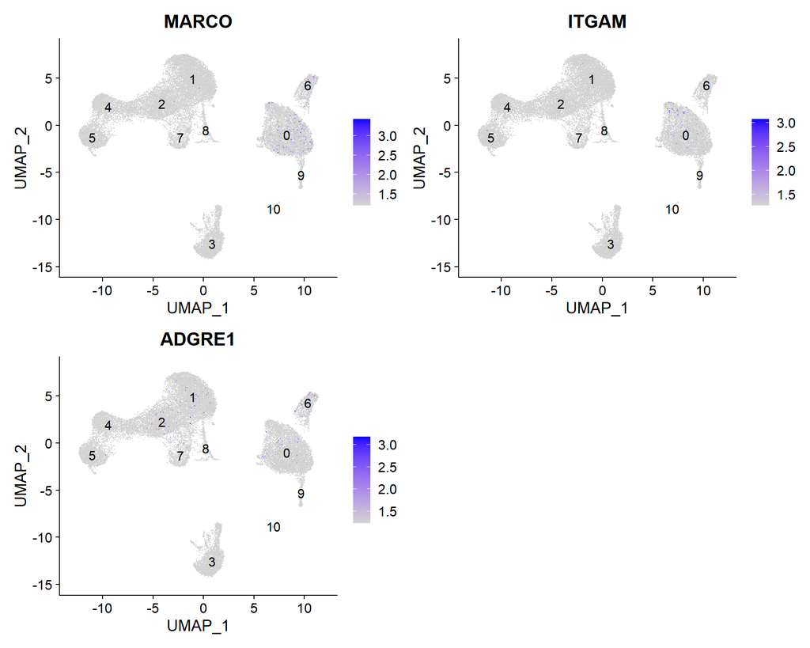

```r
FeaturePlot(combined,
            reduction = "umap",
            features = c("MARCO", "ITGAM", "ADGRE1"),
            order = TRUE,
            min.cutoff = 'q10',
            ncol = 2,
            label = TRUE)
```

**Conventional dendritic cell markers**

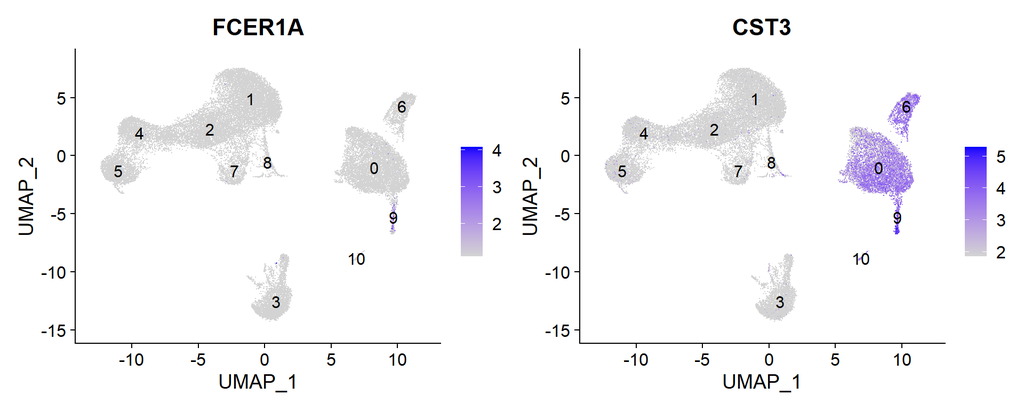

```r
FeaturePlot(combined,
            reduction = "umap",
            features = c("FCER1A", "CST3"),
            order = TRUE,
            min.cutoff = 'q10',
            label = TRUE)
```

**Plasmacytoid dendritic cell markers**

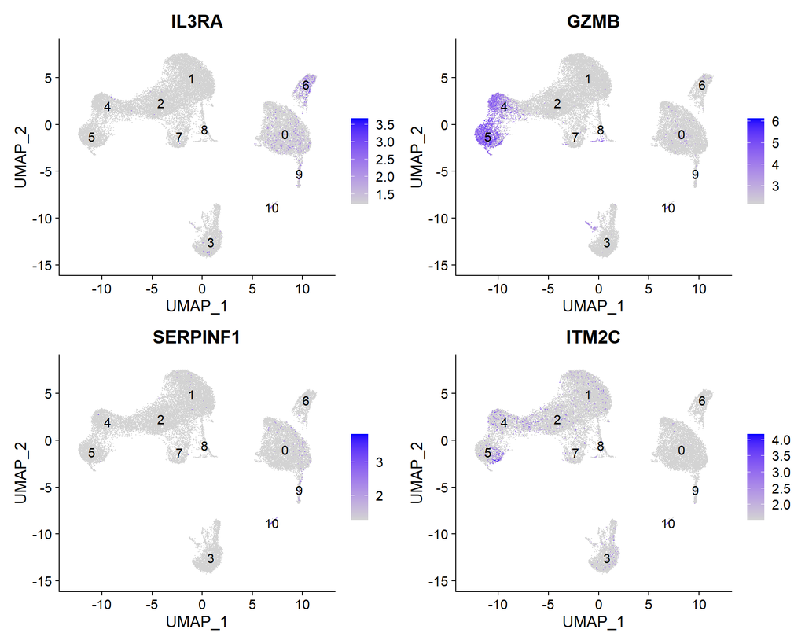

```r
FeaturePlot(combined,
            reduction = "umap",
            features = c("IL3RA", "GZMB", "SERPINF1", "ITM2C"),
            order = TRUE,
            min.cutoff = 'q10',
            ncol = 2,
            label = TRUE)
```

**B cells**

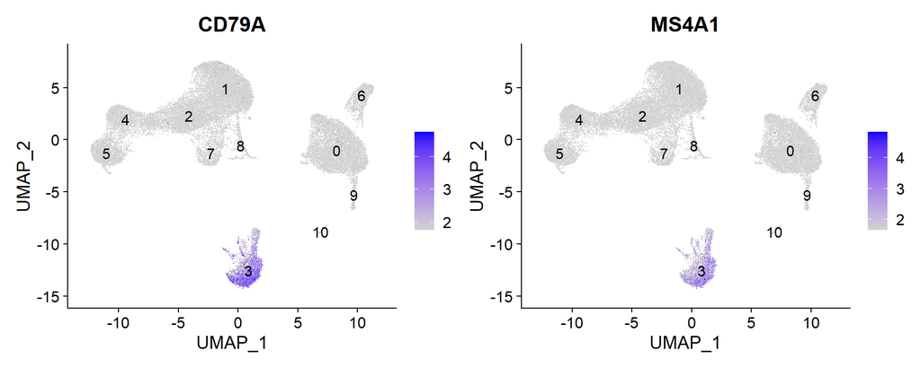

```r
FeaturePlot(combined,
            reduction = "umap",
            features = c("CD79A", "MS4A1"),
            order = TRUE,
            min.cutoff = 'q10',
            ncol = 2,
            label = TRUE)
```

**T cells and subtypes**

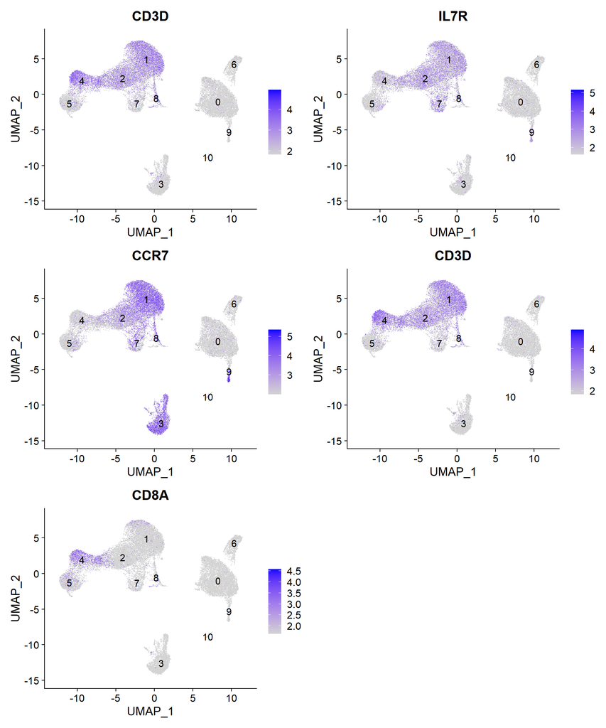

[output not shown]

```r
FeaturePlot(
  combined,
  reduction = "umap",
  features = c("CD3D", "IL7R", "CCR7", "CD3D", "CD8A"),
  order = TRUE,
  min.cutoff = 'q10',
  ncol = 2,
  label = TRUE
)
```

**NK cells, Megakaryocytes, Erythrocytes**

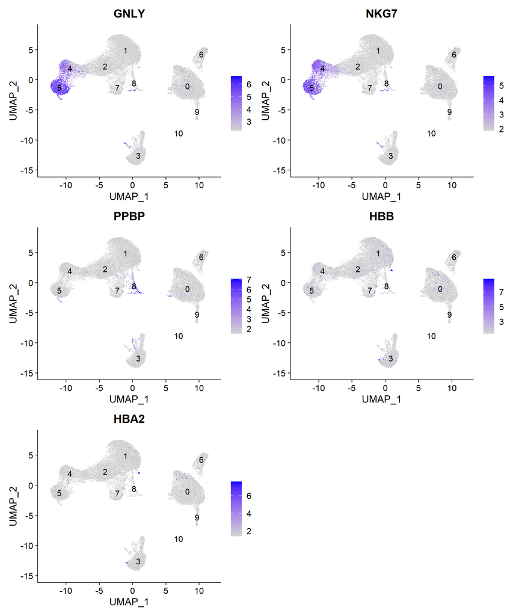

```r
FeaturePlot(
  combined,
  reduction = "umap",
  features = c("GNLY", "NKG7", "PPBP", "HBB", "HBA2"),
  order = TRUE,
  min.cutoff = 'q10',
  ncol = 2,
  label = TRUE
)
```

# Cell type annotation

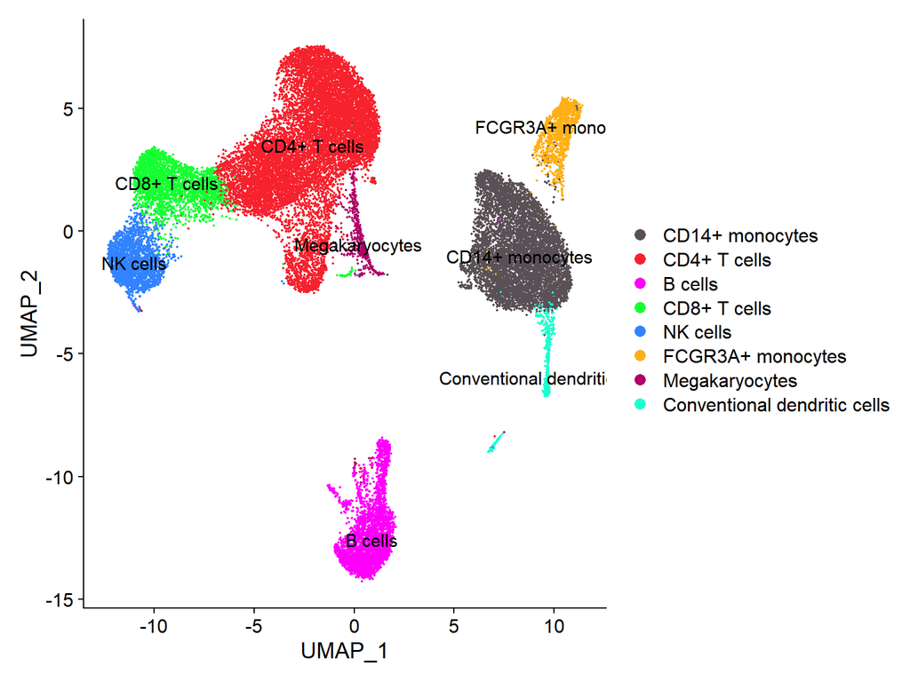

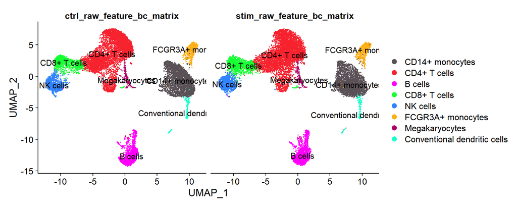

# 3 Barplots of cells between cell type and samples

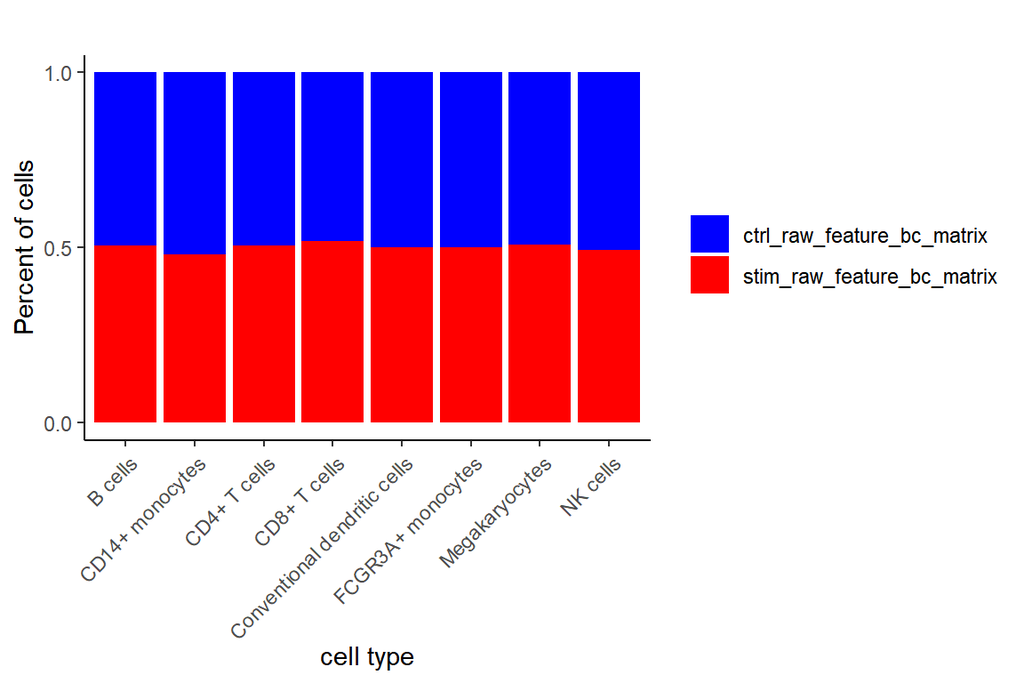

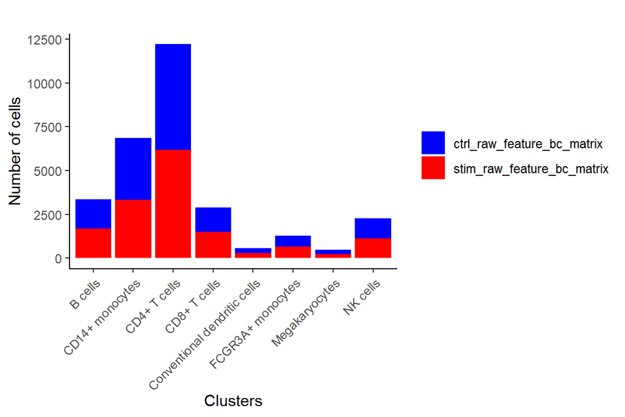